# COMPSCIX 415.2 Homework 9/Final

Chisun Fan

March 28, 2019

```r
library(tidyverse)
library(broom)
```

Exercises (Total Points - 20)

## Exercise 1 - Sampling Distributions, Functions and For Loops (10 points)

Write an R function that does the following:

Takes a sample of size samp_size from this exponential distribution (samp_size is an input parameter for the function) Calculates the mean of that sample Calculates the standard deviation of that sample Returns the calculated mean and standard deviation as a list Helper code

samp_fun <- function(samp_size, samp_rate) {

stats <- list(samp_avg = samp_avg, samp_std_dev = samp_std_dev) return(stats) }

```r
samp_fun <- function(samp_size,samp_rate){

samples =  rexp(samp_size,rate=samp_rate)
samp_avg = mean(samples)
samp_std_dev = sd(samples)
stats <- list(samp_avg=samp_avg,samp_std_dev = samp_std_dev)
return(stats)
}
```

STEP 2

Then write a loop that does this:

Runs the above function 1000 times, with samp_size = 50 and samp_rate = 1/10000 Saves all of the sample means in a vector called sample_means, and all of the sample standard deviations in a vector called sample_sds

```r
samp_means <- rep(NA,1000)
samp_sds <- rep(NA,1000)
samp_size <- 50
samp_rate <- 1/10000
for(i in 1:1000) {
 stats <-  samp_fun(samp_size,samp_rate)
 samp_means[i] <-stats$samp_avg
 samp_sds[i] <- stats$samp_std_dev
}
```

STEP 3

Then

plot your sample means as a histogram

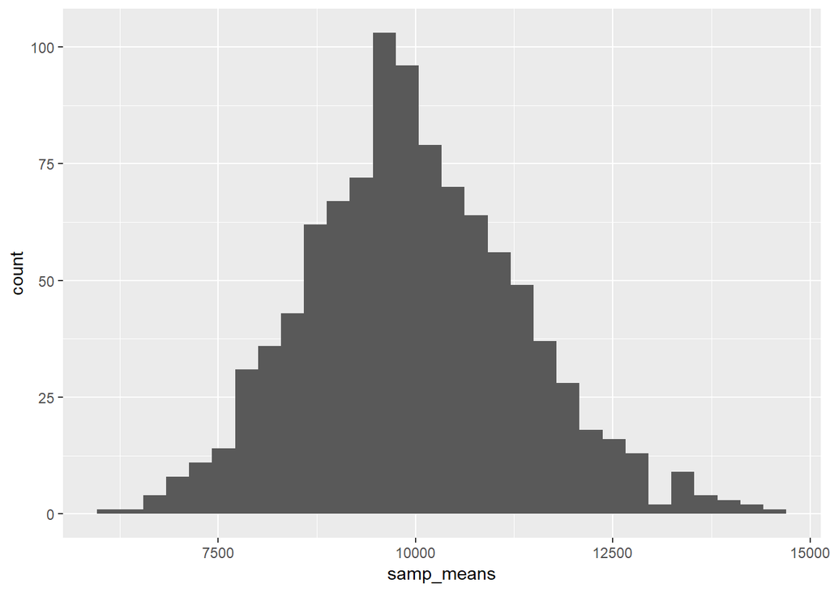

```r
as.data.frame(samp_means) %>% ggplot(mapping=aes(x=samp_means))+geom_histogram()
```

output the standard deviation of your sample means

```r
 sd(samp_means)
```

```
## [1] 1371.987
```

calculate the theoretical standard error (σ=10000, n = sample size)

```r
10000/sqrt(50)
```

```
## [1] 1414.214
```

calculate the mean of the sample standard deviations and use this to calculate the empirical standard error

```r
mean_sd <- mean(samp_sds)
mean_sd/sqrt(50)
```

```
## [1] 1387.851
```

STEP 4

Repeat STEP 2 and STEP 3 using a sample size of 5000.

```r
samp_means <- rep(NA,1000)
samp_sds <- rep(NA,1000)
samp_size <- 5000
samp_rate <- 1/10000
for(i in 1:1000) {
 stats <-  samp_fun(samp_size,samp_rate)
 samp_means[i] <-stats$samp_avg
 samp_sds[i] <- stats$samp_std_dev
}
```

plot your sample means as a histogram

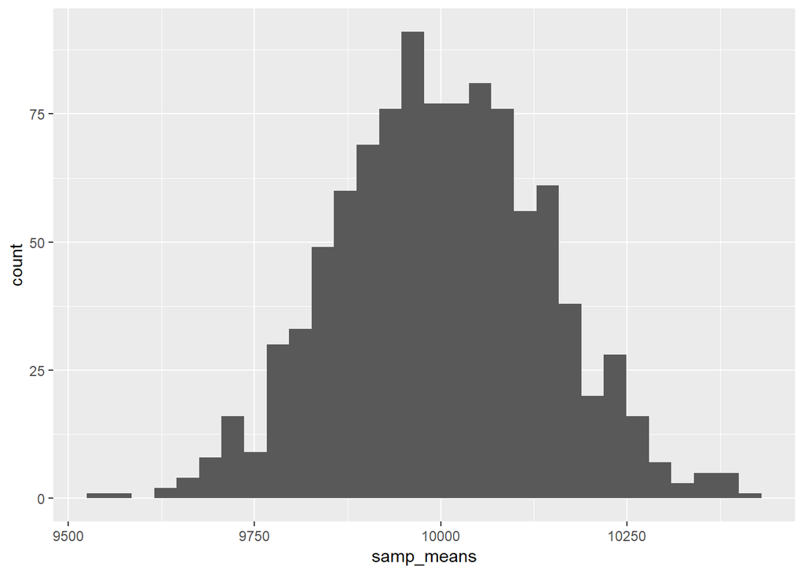

```r
as.data.frame(samp_means) %>% ggplot(mapping=aes(x=samp_means))+geom_histogram()
```

output the standard deviation of your sample means

```r
 sd(samp_means)
```

```
## [1] 139.4354
```

calculate the theoretical standard error (σ=10000, n = sample size)

```r
10000/sqrt(5000)
```

```
## [1] 141.4214
```

calculate the mean of the sample standard deviations and use this to calculate the empirical standard error

```r
mean_sd <- mean(samp_sds)
mean_sd/sqrt(5000)
```

```
## [1] 141.2847
```

## Exercise 2 - Linear Regression (5 points)

For this exercise we will return to the House Prices prediction dataset that we used for HW 7. You should have already downloaded the train.csv dataset before, but if you didn’t you can download it from Canvas in this week’s module.

Load the train.csv dataset into R and fit a regression model with:

y = SalePrice Features: LotArea, OverallQual, and ExterQual Answer these questions:

Use the broom package to output the coefficients and the R-squared

```r
File_path <- "C:/users/chisun/downloads/train.csv"
train_csv <- read_delim(File_path,',')
fit <- lm(SalePrice ~ LotArea+OverallQual+ExterQual, data = train_csv)
summary(fit)
```

```
##
## Call:
## lm(formula = SalePrice ~ LotArea + OverallQual + ExterQual, data = train_csv)
##
## Residuals:
##     Min      1Q  Median      3Q     Max
## -318248  -24842   -1716   18613  408405
##
## Coefficients:
##               Estimate Std. Error t value Pr(>|t|)
## (Intercept)  4.076e+04  1.236e+04   3.299 0.000995 ***
## LotArea      1.453e+00  1.162e-01  12.506  < 2e-16 ***
## OverallQual  3.447e+04  1.216e+03  28.341  < 2e-16 ***
## ExterQualFa -9.535e+04  1.459e+04  -6.535  8.8e-11 ***
## ExterQualGd -7.153e+04  6.737e+03 -10.617  < 2e-16 ***
## ExterQualTA -9.753e+04  7.541e+03 -12.932  < 2e-16 ***
## ---
## Signif. codes:  0 '***' 0.001 '**' 0.01 '*' 0.05 '.' 0.1 ' ' 1
##
## Residual standard error: 43950 on 1454 degrees of freedom
## Multiple R-squared:  0.695,  Adjusted R-squared:  0.694
## F-statistic: 662.7 on 5 and 1454 DF,  p-value: < 2.2e-16
```

```r
tidy(fit)
```

```
## # A tibble: 6 x 5
##   term         estimate std.error statistic   p.value
##   <chr>           <dbl>     <dbl>     <dbl>     <dbl>
## 1 (Intercept)  40764.   12358.         3.30 9.95e-  4
## 2 LotArea          1.45     0.116     12.5  3.72e- 34
## 3 OverallQual  34466.    1216.        28.3  4.77e-141
## 4 ExterQualFa -95352.   14592.        -6.53 8.80e- 11
## 5 ExterQualGd -71529.    6737.       -10.6  2.05e- 25
## 6 ExterQualTA -97527.    7541.       -12.9  2.72e- 36
```

```r
glance(fit)
```

```
## # A tibble: 1 x 11
##   r.squared adj.r.squared  sigma statistic p.value    df  logLik    AIC
##       <dbl>         <dbl>  <dbl>     <dbl>   <dbl> <int>   <dbl>  <dbl>
## 1     0.695         0.694 43948.      663.       0     6 -17677. 35368.
## # ... with 3 more variables: BIC <dbl>, deviance <dbl>, df.residual <int>
```

Interpret the coefficient on LotArea

**The coefficient 1.45 indicates the value per square foot of lot size**

Interpret the coefficient on ExterQualGd

**The coefficient -70000 is salePrice adjustment from the mean value when external grade is Gd.**

## Exercise 3 - AB Testing (5 points)

Download the ab_test_data.csv file from Canvas. This file contains two columns: version and conversion. Each row is a visitor to a webpage. The version column tells us which version of the webpage the visitor saw, and the conversion column is a binary value and equals 1 if the visitor converted (0 otherwise).

We want to perform an AB test on this data to see if the conversion rates are different for the two versions of the webpage.

Answer these questions:

```r
File_path <- "C:/users/chisun/downloads/ab_test_data.csv"
data_csv <- read.csv(File_path)
A_total <- nrow(filter(data_csv,version == 'A'))
B_total <- nrow(filter(data_csv,version == 'B'))
A_convert <- nrow(filter(data_csv,version == 'A' & conversion == 1))
B_convert <- nrow(filter(data_csv,version == 'B' & conversion == 1))
A_convert/A_total
```

```
## [1] 0.0415
```

```r
B_convert/B_total
```

```
## [1] 0.1
```

```r
two_prop_test <- prop.test(c(A_convert,B_convert),c(A_total,B_total))
two_prop_test
```

```
##
##  2-sample test for equality of proportions with continuity
##  correction
##
## data:  c(A_convert, B_convert) out of c(A_total, B_total)
## X-squared = 51.168, df = 1, p-value = 8.48e-13
## alternative hypothesis: two.sided
## 95 percent confidence interval:
##  -0.07478822 -0.04221178
## sample estimates:
## prop 1 prop 2
## 0.0415 0.1000
```

What proportion of visitors converted for each version of the webpage?

**Around 4 percent for A and 10 percent for B.**

Perform the AB test in R. What is the p-value for the AB test (hypothesis test of proportions)?

**P value is extermely small. which indicates the conversion rate is reliable.**